# Hierarchical GAM on fish population trends

Model we are attempting to build:

$$N_{i,t} = f(t, \alpha_i) + g(\lambda_i,
\beta_i) + \varepsilon_i$$

Where:

- $N$ : population size estimate
- $i$ : population
- $t$ : time step
- $f(t, \alpha_i)$ : function estimating the temporal trend in population size
  - $\alpha$: estimated parameter describing each population’s temporal slope
- $g(\lambda, \beta_i)$ : function estimating latent variation in population size
  - $\lambda$ : latent variable (to capture covariation between populations)
  - $\beta$ : estimated parameter describing each population’s latent variation
- $\varepsilon$: residual variation

Because the model also estimates latent variation, we are accounting for the covariation between populations when estimating $N$.

This model then contains key information to calculate and extend an index like the Living Planet Index, to show the average change in population size from a baseline value of 1 in the start year.

The first part of the model estimates the temporal trend of each population’s size ($\alpha_i$), which contains information about population-level change *and* community-level change:

$$\alpha_i \sim N(\mu_{\alpha},
\sigma^2_{\alpha})$$

To calculate the index of change from a baseline of 1 (as in the LPI), the average population trend can then be plugged in to the LPI calculation as follows:

$$I_t = {\mu_{\alpha}}*t + 1$$

This trend can then be visualized and communicated with its known ($\sigma^2_{\alpha}$).

```r
#### import & set up data ####

# from https://github.com/eric-pedersen/groundfish-data-analysis
# note: these are mean biomasses over the whole sampled area with an SE
# not actually raw abundances. But for this purpose, should be ok
load("~/Documents/GitHub/groundfish-data-analysis/data/year_geom_means.Rdata")

time = rownames(Year_Geom_Means_all) %>% as.numeric()

# get number of populations & length of time series
npops <- ncol(Year_Geom_Means_all)
tsl <- nrow(Year_Geom_Means_all)
```

## Building the model with mgcv

```r
# scale all columns
Year_Geom_Means_all = apply(Year_Geom_Means_all, 2, scale) %>% as.data.frame()
Year_Geom_Means_all$time = as.integer(time)
df = Year_Geom_Means_all %>%
  pivot_longer(cols = -time,
               names_to = "species", "values_to" = "N")
df$species <- factor(df$species)

# build a GI model: global smoother plus group-level smoothers with differing wiggliness

m <- gam(N ~ # global smooth
           s(time, bs = c("tp"), m = 2, k = 30) +
           # smooth per species
           s(time, by = species, bs = c("tp"), m = 1, k = 30) +
           # random intercept
           s(species, bs = c("re"), k = 30),
         data = df,
         method="REML",
         family="gaussian")

# save model
saveRDS(m, here("models/hgam.RDS"))
```

### Model performance

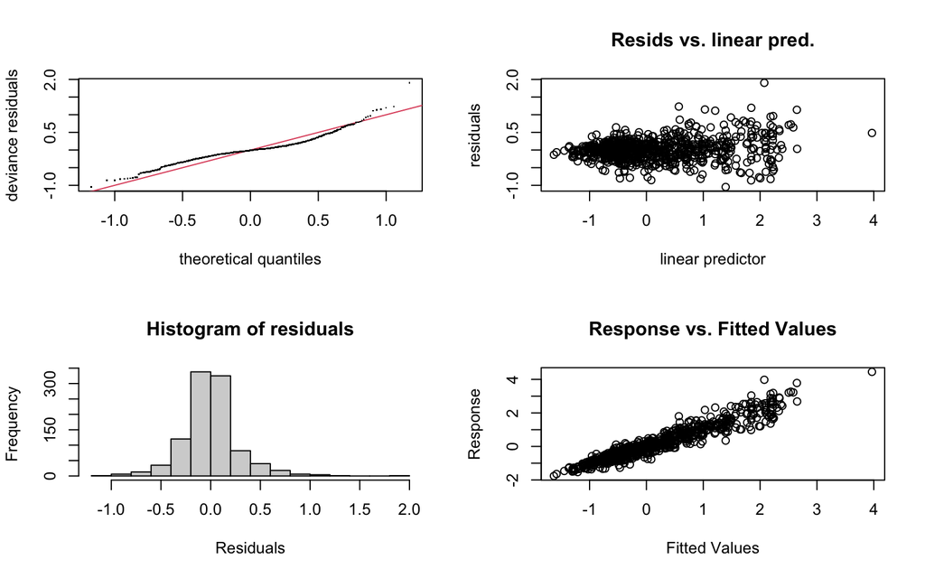

```
##
## Method: REML   Optimizer: outer newton
## full convergence after 12 iterations.
## Gradient range [-8.007026e-05,0.0002563674]
## (score 847.2227 & scale 0.127037).
## Hessian positive definite, eigenvalue range [5.860272e-06,497.7371].
## Model rank =  930 / 930
##
## Basis dimension (k) checking results. Low p-value (k-index<1) may
## indicate that k is too low, especially if edf is close to k'.
##
##                                                      k'      edf k-index
## s(time)                                        2.90e+01 1.43e+01    0.97
## s(time):speciesANARHICHAS_DENTICULATUS         2.90e+01 1.60e-04    0.97
## s(time):speciesANARHICHAS_LUPUS                2.90e+01 2.21e-04    0.97
## s(time):speciesANARHICHAS_MINOR                2.90e+01 1.87e-04    0.97
## s(time):speciesCENTROSCYLLIUM_FABRICII         2.90e+01 1.98e+01    0.97
## s(time):speciesCORYPHAENOIDES_RUPESTRIS        2.90e+01 2.31e+01    0.97
## s(time):speciesCOTTUNCULUS_MICROPS             2.90e+01 2.27e+01    0.97
## s(time):speciesCYCLOPTERUS_LUMPUS              2.90e+01 2.30e+01    0.97
## s(time):speciesENCHELYOPUS_CIMBRIUS            2.90e+01 1.68e+01    0.97
## s(time):speciesEUMICROTREMUS_SP                2.90e+01 1.93e+01    0.97
## s(time):speciesGADUS_MORHUA                    2.90e+01 6.76e-01    0.97
## s(time):speciesGLYPTOCEPHALUS_CYNOGLOSSUS      2.90e+01 1.77e-04    0.97
## s(time):speciesHIPPOGLOSSOIDES_PLATESSOIDES    2.90e+01 2.40e-04    0.97
## s(time):speciesLIMANDA_FERRUGINEA              2.90e+01 2.16e+01    0.97
## s(time):speciesLYCODES_ESMARKI                 2.90e+01 1.10e+01    0.97
## s(time):speciesLYCODES_RETICULATUS             2.90e+01 1.35e+01    0.97
## s(time):speciesLYCODES_VAHLII                  2.90e+01 2.03e+01    0.97
## s(time):speciesMACROURUS_BERGLAX               2.90e+01 1.64e+01    0.97
## s(time):speciesMYOXOCEPHALUS_OCTODECEMSPINOSUS 2.90e+01 2.35e+01    0.97
## s(time):speciesMYOXOCEPHALUS_SCORPIUS          2.90e+01 2.14e+01    0.97
## s(time):speciesNEZUMIA_BAIRDI                  2.90e+01 1.74e+01    0.97
## s(time):speciesNOTACANTHIDAE                   2.90e+01 2.15e+01    0.97
## s(time):speciesNOTACANTHUS_NASUS               2.90e+01 1.83e+01    0.97
## s(time):speciesRAJA_RADIATA                    2.90e+01 4.47e+00    0.97
## s(time):speciesRAJA_SENTA                      2.90e+01 2.70e-04    0.97
## s(time):speciesRAJA_SPINICAUDA                 2.90e+01 3.76e-05    0.97
## s(time):speciesREINHARDTIUS_HIPPOGLOSSOIDES    2.90e+01 1.35e+01    0.97
## s(time):speciesSEBASTES_MARINUS                2.90e+01 4.95e-01    0.97
```

[output cut: 22 more lines]

```
## s(time):speciesMACROURUS_BERGLAX                  0.15
## s(time):speciesMYOXOCEPHALUS_OCTODECEMSPINOSUS    0.18
## s(time):speciesMYOXOCEPHALUS_SCORPIUS             0.21
## s(time):speciesNEZUMIA_BAIRDI                     0.28
## s(time):speciesNOTACANTHIDAE                      0.20
## s(time):speciesNOTACANTHUS_NASUS                  0.15
## s(time):speciesRAJA_RADIATA                       0.15
## s(time):speciesRAJA_SENTA                         0.18
## s(time):speciesRAJA_SPINICAUDA                    0.18
## s(time):speciesREINHARDTIUS_HIPPOGLOSSOIDES       0.19
## s(time):speciesSEBASTES_MARINUS                   0.18
## s(time):speciesSEBASTES_MENTELLA                  0.14
## s(time):speciesUROPHYCIS_CHESTERI                 0.15
## s(time):speciesUROPHYCIS_TENUIS                   0.18
## s(species)                                          NA
```

```r
gam.check(m)
```

```r
k.check(m)
```

```
##                                                k'          edf   k-index
## s(time)                                        29 1.429787e+01 0.9722093
## s(time):speciesANARHICHAS_DENTICULATUS         29 1.596183e-04 0.9722093
## s(time):speciesANARHICHAS_LUPUS                29 2.206391e-04 0.9722093
## s(time):speciesANARHICHAS_MINOR                29 1.867273e-04 0.9722093
## s(time):speciesCENTROSCYLLIUM_FABRICII         29 1.983307e+01 0.9722093
## s(time):speciesCORYPHAENOIDES_RUPESTRIS        29 2.313543e+01 0.9722093
## s(time):speciesCOTTUNCULUS_MICROPS             29 2.268324e+01 0.9722093
## s(time):speciesCYCLOPTERUS_LUMPUS              29 2.296973e+01 0.9722093
## s(time):speciesENCHELYOPUS_CIMBRIUS            29 1.675716e+01 0.9722093
## s(time):speciesEUMICROTREMUS_SP                29 1.931262e+01 0.9722093
## s(time):speciesGADUS_MORHUA                    29 6.762329e-01 0.9722093
## s(time):speciesGLYPTOCEPHALUS_CYNOGLOSSUS      29 1.770804e-04 0.9722093
## s(time):speciesHIPPOGLOSSOIDES_PLATESSOIDES    29 2.399142e-04 0.9722093
## s(time):speciesLIMANDA_FERRUGINEA              29 2.155065e+01 0.9722093
## s(time):speciesLYCODES_ESMARKI                 29 1.100258e+01 0.9722093
## s(time):speciesLYCODES_RETICULATUS             29 1.349376e+01 0.9722093
## s(time):speciesLYCODES_VAHLII                  29 2.030476e+01 0.9722093
## s(time):speciesMACROURUS_BERGLAX               29 1.639436e+01 0.9722093
## s(time):speciesMYOXOCEPHALUS_OCTODECEMSPINOSUS 29 2.345030e+01 0.9722093
## s(time):speciesMYOXOCEPHALUS_SCORPIUS          29 2.137415e+01 0.9722093
## s(time):speciesNEZUMIA_BAIRDI                  29 1.744549e+01 0.9722093
## s(time):speciesNOTACANTHIDAE                   29 2.145929e+01 0.9722093
## s(time):speciesNOTACANTHUS_NASUS               29 1.833784e+01 0.9722093
## s(time):speciesRAJA_RADIATA                    29 4.469879e+00 0.9722093
## s(time):speciesRAJA_SENTA                      29 2.700832e-04 0.9722093
## s(time):speciesRAJA_SPINICAUDA                 29 3.755160e-05 0.9722093
## s(time):speciesREINHARDTIUS_HIPPOGLOSSOIDES    29 1.345965e+01 0.9722093
## s(time):speciesSEBASTES_MARINUS                29 4.953537e-01 0.9722093
## s(time):speciesSEBASTES_MENTELLA               29 9.240956e+00 0.9722093
## s(time):speciesUROPHYCIS_CHESTERI              29 1.699987e+01 0.9722093
## s(time):speciesUROPHYCIS_TENUIS                29 2.014342e+01 0.9722093
## s(species)                                     30 1.601405e-04        NA
##                                                p-value
## s(time)                                         0.1800
## s(time):speciesANARHICHAS_DENTICULATUS          0.1625
## s(time):speciesANARHICHAS_LUPUS                 0.1750
## s(time):speciesANARHICHAS_MINOR                 0.2025
## s(time):speciesCENTROSCYLLIUM_FABRICII          0.1900
## s(time):speciesCORYPHAENOIDES_RUPESTRIS         0.1925
```

[output cut: 11 more lines]

```
## s(time):speciesMACROURUS_BERGLAX                0.1900
## s(time):speciesMYOXOCEPHALUS_OCTODECEMSPINOSUS  0.1800
## s(time):speciesMYOXOCEPHALUS_SCORPIUS           0.1825
## s(time):speciesNEZUMIA_BAIRDI                   0.1750
## s(time):speciesNOTACANTHIDAE                    0.2025
## s(time):speciesNOTACANTHUS_NASUS                0.2000
## s(time):speciesRAJA_RADIATA                     0.1850
## s(time):speciesRAJA_SENTA                       0.1875
## s(time):speciesRAJA_SPINICAUDA                  0.1650
## s(time):speciesREINHARDTIUS_HIPPOGLOSSOIDES     0.2025
## s(time):speciesSEBASTES_MARINUS                 0.1975
## s(time):speciesSEBASTES_MENTELLA                0.1950
## s(time):speciesUROPHYCIS_CHESTERI               0.1800
## s(time):speciesUROPHYCIS_TENUIS                 0.2000
## s(species)                                          NA
```

```r
# draw(m)

summary(m)
```

```
##
## Family: gaussian
## Link function: identity
##
## Formula:
## N ~ s(time, bs = c("tp"), m = 2, k = 30) + s(time, by = species,
##     bs = c("tp"), m = 1, k = 30) + s(species, bs = c("re"), k = 30)
##
## Parametric coefficients:
##               Estimate Std. Error t value Pr(>|t|)
## (Intercept) -2.990e-15  1.133e-02       0        1
##
## Approximate significance of smooth terms:
##                                                      edf Ref.df       F
## s(time)                                        1.430e+01  17.06 119.202
## s(time):speciesANARHICHAS_DENTICULATUS         1.596e-04  29.00   0.000
## s(time):speciesANARHICHAS_LUPUS                2.206e-04  29.00   0.000
## s(time):speciesANARHICHAS_MINOR                1.867e-04  29.00   0.000
## s(time):speciesCENTROSCYLLIUM_FABRICII         1.983e+01  29.00   2.808
## s(time):speciesCORYPHAENOIDES_RUPESTRIS        2.314e+01  29.00  13.588
## s(time):speciesCOTTUNCULUS_MICROPS             2.268e+01  29.00  13.305
## s(time):speciesCYCLOPTERUS_LUMPUS              2.297e+01  29.00  16.063
## s(time):speciesENCHELYOPUS_CIMBRIUS            1.676e+01  29.00  19.909
## s(time):speciesEUMICROTREMUS_SP                1.931e+01  29.00  24.101
## s(time):speciesGADUS_MORHUA                    6.762e-01  29.00   0.029
## s(time):speciesGLYPTOCEPHALUS_CYNOGLOSSUS      1.771e-04  29.00   0.000
## s(time):speciesHIPPOGLOSSOIDES_PLATESSOIDES    2.399e-04  29.00   0.000
## s(time):speciesLIMANDA_FERRUGINEA              2.155e+01  29.00  11.117
## s(time):speciesLYCODES_ESMARKI                 1.100e+01  29.00   1.468
## s(time):speciesLYCODES_RETICULATUS             1.349e+01  29.00   1.498
## s(time):speciesLYCODES_VAHLII                  2.030e+01  29.00  10.937
## s(time):speciesMACROURUS_BERGLAX               1.639e+01  29.00   5.636
## s(time):speciesMYOXOCEPHALUS_OCTODECEMSPINOSUS 2.345e+01  29.00  10.009
## s(time):speciesMYOXOCEPHALUS_SCORPIUS          2.137e+01  29.00  17.947
## s(time):speciesNEZUMIA_BAIRDI                  1.745e+01  29.00  21.496
## s(time):speciesNOTACANTHIDAE                   2.146e+01  29.00  19.027
## s(time):speciesNOTACANTHUS_NASUS               1.834e+01  29.00  11.648
## s(time):speciesRAJA_RADIATA                    4.470e+00  29.00   0.292
## s(time):speciesRAJA_SENTA                      2.701e-04  29.00   0.000
## s(time):speciesRAJA_SPINICAUDA                 3.755e-05  29.00   0.000
```

[output cut: 29 more lines]

```
## s(time):speciesNOTACANTHUS_NASUS                < 2e-16 ***
## s(time):speciesRAJA_RADIATA                      0.0455 *
## s(time):speciesRAJA_SENTA                        0.5395
## s(time):speciesRAJA_SPINICAUDA                   0.5153
## s(time):speciesREINHARDTIUS_HIPPOGLOSSOIDES     < 2e-16 ***
## s(time):speciesSEBASTES_MARINUS                  0.2412
## s(time):speciesSEBASTES_MENTELLA                < 2e-16 ***
## s(time):speciesUROPHYCIS_CHESTERI               < 2e-16 ***
## s(time):speciesUROPHYCIS_TENUIS                 < 2e-16 ***
## s(species)                                       1.0000
## ---
## Signif. codes:  0 '***' 0.001 '**' 0.01 '*' 0.05 '.' 0.1 ' ' 1
##
## R-sq.(adj) =  0.869   Deviance explained = 92.1%
## -REML = 847.22  Scale est. = 0.12704   n = 990
```

## Predicting the full model

### Predict global smooth (overall temporal trend)

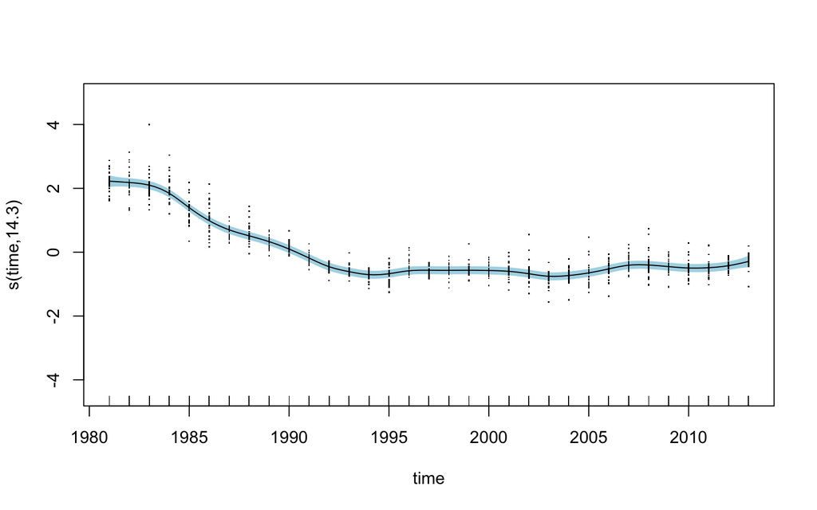

```r
# plot the global smooth s(time)
plot(m,
     residuals = TRUE, shade = TRUE, shade.col = "lightblue",
     select = 1,
     seWithMean = TRUE,
     shift = unname(coef(m)[1]))
```

### Predict species smooths

```r
# Evaluate the smooth over a range of values for `year`
time_smest <- smooth_estimates(m, "s(time)", n = tsl)
# add a confidence interval
time_sm <- confint(m, "s(time)", n = tsl)
```

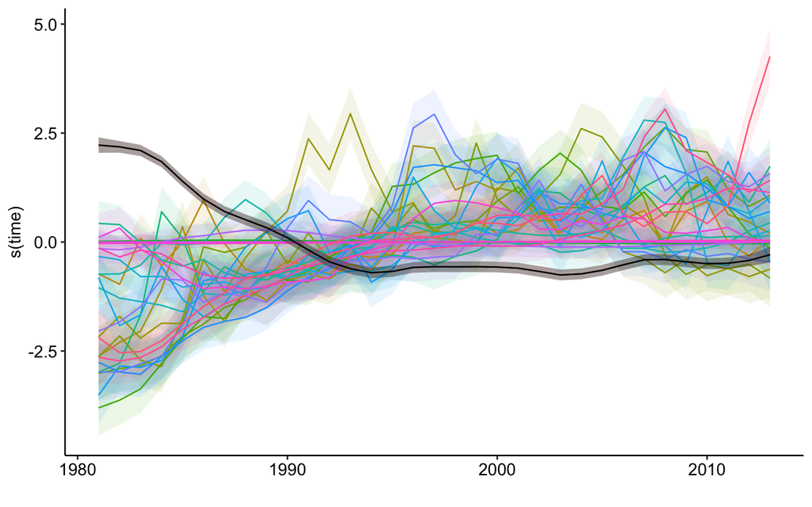

```r
ggplot(data = time_sm, aes(x = time)) +
  geom_ribbon(aes(ymin = lower, ymax = upper, fill = smooth), alpha = .1) +
  geom_line(aes(y = est, col = smooth)) +
  geom_ribbon(data = filter(time_sm, smooth == "s(time)"),
              aes(x = time, ymin = lower, ymax = upper), alpha = .4) +
  geom_line(data = filter(time_sm, smooth == "s(time)"),
            aes(x = time, y = est)) +
  labs(y = "s(time)", x = "") +
  ggpubr::theme_pubr() +
  theme(legend.position = "none")
```

## Extracting model coefficients: alpha

```r
time_smest
```

```
## # A tibble: 33 × 6
##    smooth  type  by       est     se  time
##    <chr>   <chr> <chr>  <dbl>  <dbl> <int>
##  1 s(time) TPRS  <NA>  2.22   0.0902  1981
##  2 s(time) TPRS  <NA>  2.18   0.0682  1982
##  3 s(time) TPRS  <NA>  2.10   0.0657  1983
##  4 s(time) TPRS  <NA>  1.84   0.0642  1984
##  5 s(time) TPRS  <NA>  1.39   0.0636  1985
##  6 s(time) TPRS  <NA>  0.986  0.0634  1986
##  7 s(time) TPRS  <NA>  0.700  0.0633  1987
##  8 s(time) TPRS  <NA>  0.513  0.0632  1988
##  9 s(time) TPRS  <NA>  0.330  0.0632  1989
## 10 s(time) TPRS  <NA>  0.0979 0.0632  1990
## # … with 23 more rows
```

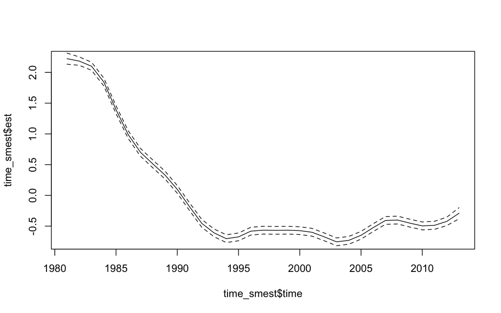

```r
plot(x = time_smest$time, y = time_smest$est, type = "l")
lines(x = time_smest$time,
      y = time_smest$est + time_smest$se, lty = 2)
lines(x = time_smest$time,
      y = time_smest$est - time_smest$se, lty = 2)
```

## Extract covariance between populations

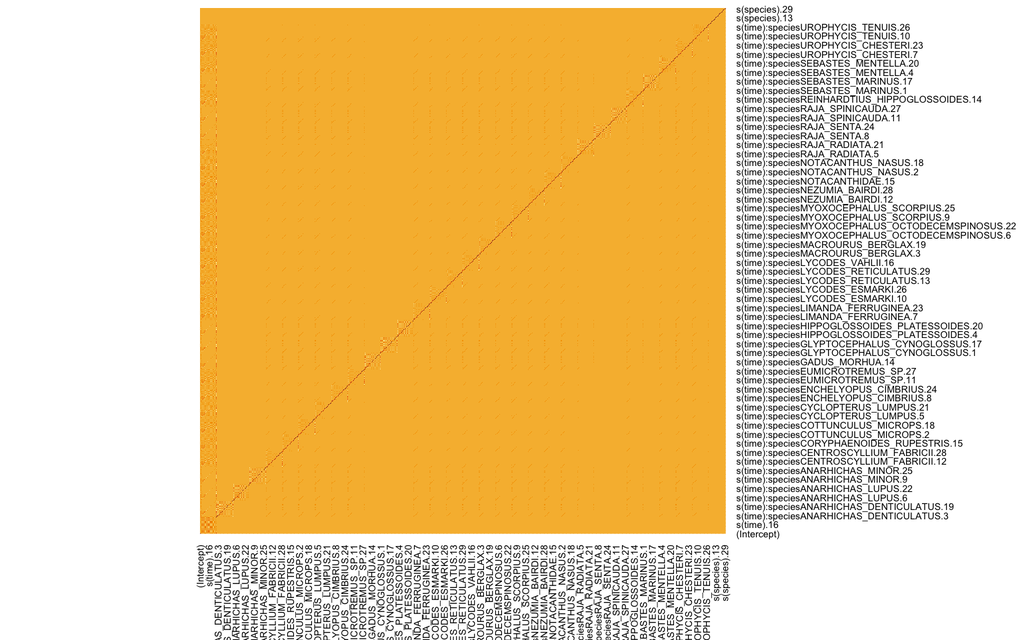

```r
Vb <- vcov(m) # default is the bayesian covariance matrix
heatmap(Vb, Rowv = NA, Colv = NA)
```

```r
# Vb_sponly <- Vb[which(grepl("species", rownames(Vb))),
#                 which(grepl("species", colnames(Vb)))]
# Vb_sponly_ls <- list()
# for(i in 1:30){
#   Vb_sponly_ls[[i]] <- Vb_sponly[
#     which(grepl(paste0(i), rownames(Vb_sponly))),
#     which(grepl(paste0(i), colnames(Vb_sponly)))]
# }
#
# Vb_cor = cov2cor(Vb_sponly)
#
# for(i in 1:29){
# corrplot::corrplot(Vb_sponly_ls[[i]],
#                    method = "color",
#                    type = "lower",
#                    tl.pos = "n")
# }
```

## Extract global population trend

Note: this is *just* the temporal trend, without the latent variation or the residual error.

### Average slope of the temporal trend in population size (LPI-pop)

```r
lpipop = filter(time_sm, smooth == "s(time)")$est
```

### Variance in the temporal trend across populations (LPI-comm)

```r
lpicomm = filter(time_sm, smooth == "s(time)")$se
# not sure about this one...
```

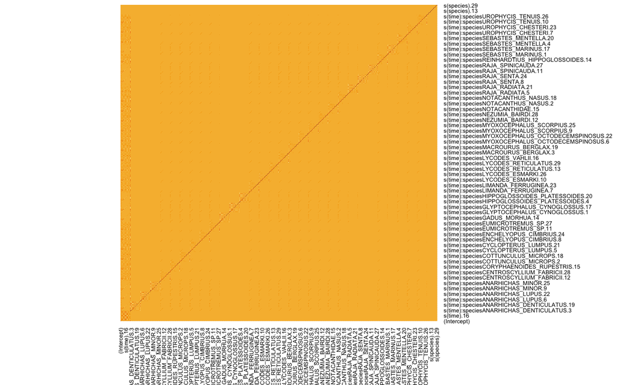

```r
# drawing posteriors for the predicted response values:

beta <- coef(m)   # vector of model parameters

Vb <- vcov(m)     # default is the bayesian covariance matrix
heatmap(Vb, Rowv = NA, Colv = NA)
```

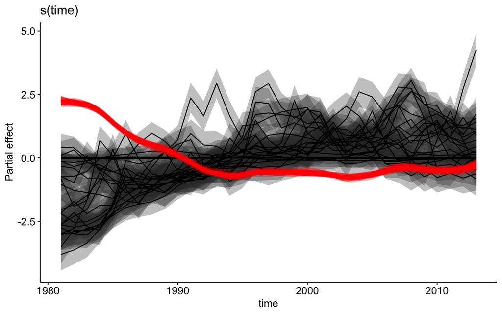

```r
# sample from the posterior distribution
m_post <- smooth_samples(m, 's(time)', n = 100, seed = 42)

post_summary <- m_post %>%
  group_by(.x1) %>%
  summarise(mu = mean(value, na.rm = TRUE),
            lower = quantile(value, 0.025),
            upper = quantile(value, 0.975),
            variance = var(value)) %>% ungroup()

time_fit <- evaluate_smooth(m, 's(time)', n = tsl)

draw(time_fit) +
  geom_line(data = m_post,
            aes(x = .x1, y = value, group = draw),
            alpha = 0.3, colour = 'red')
```